# Basketball Data Science & Solutions Project

Aris Antoniadis

2023-08

# Introduction

As a longtime basketball fan with a growing interest in the transformative power of data, I decided to take on an NBA data science project over the summer. The goal was to leverage player, team, and award statistics to better understand performance trends and even predict future outcomes. Being from the Bay Area, my fandom for the Golden State Warriors is strong but they did not fit this project as a team of interest due to their lack of youth. However, another team I absolutely love, the Oklahoma City Thunder, proved a more interesting choice given their wealth of assets and rising stars. Though still developing, the Thunder are poised to explode in the coming years making them perfectly suited as a team of interest for this project.

For this project, I utilized several datasets spanning the 2007-2021 seasons: player stats, team stats, awards data, and 2022 specific team rebounding stats. Using R as my programming language, I explored questions like: What amount of NBA experience is required before a player’s first All-NBA selection? and what amount of points does a player typically need to score to receive certain awards? But the core aim was developing a model to predict long-term career trajectories based on early performance. With just a couple seasons of data, what factors determine if a player becomes an All-Star or a Hall of Famer down the road?

Though a general first attempt, I’m pleased with how this project turned out. Not only did I strengthen my data science and R abilities, I also boosted my basketball IQ in the process! With the new knowledge I have, I’d love to continue refining my analytical approach to this sport in future projects or learn even more through non-sports focused projects! Hopefully you’ll discover some interesting takeaways in exploring the code and analysis that follows!

# Setup and Data

```r
library(tidyverse)
library(dplyr)
library(randomForest)
library(nnet)
library(rpart.plot)
library(rpart)
awards <- read_csv("awards_data.csv")
player_data <- read_csv("player_stats.csv")
team_data <- read_csv("team_stats.csv")
rebounding_data <- read_csv("team_rebounding_data_22.csv")
```

## Part 1 – Awards

In this section, I worked with data relating to player awards and statistics. I started with a couple data manipulation questions that I had out of pure curiosity and then worked towards building my model to predict broad levels of career success for inexperienced/young players. After cleaning the data in preparation for the model, I first checked to make sure everything was working by finding career outcomes for only players drafted in 2010.

### Question 1

**QUESTION:** What is the average number of points per game for players in the 2007-2021 seasons who won All NBA First, Second, and Third teams (**not** the All Defensive Teams), as well as for players who were in the All-Star Game (**not** the rookie all-star game)?

```r
# Filtered the awards dataset to include only relevant columns
awards_filtered <- awards %>%
  select(nbapersonid, season, `All NBA First Team`, `All NBA Second Team`, `All NBA Third Team`, all_star_game)

# Joined player_data and awards_filtered datasets
joined_data <- player_data %>%
  left_join(awards_filtered, by = c("nbapersonid", "season"))
# Calculated average points per game for different award categories
calculate_avg_ppg <- function(data, award_column) {
  data %>%
    filter(!is.na({{ award_column }}) & {{ award_column }}) %>%
    summarise(
      total_points = sum(points),
      total_games = sum(games)
    ) %>%
    mutate(avg_ppg = total_points / total_games)
}

# Calculated average points per game for All NBA First Team
first_team_avg <- calculate_avg_ppg(joined_data, `All NBA First Team`)

# Calculated average points per game for All NBA Second Team
second_team_avg <- calculate_avg_ppg(joined_data, `All NBA Second Team`)

# Calculated average points per game for All NBA Third Team
third_team_avg <- calculate_avg_ppg(joined_data, `All NBA Third Team`)

# Calculated average points per game for All-Star Game
all_star_avg <- joined_data %>%
  filter(!is.na(all_star_game) & all_star_game) %>%
  summarise(
    total_points = sum(points),
    total_games = sum(games)
  ) %>%
  mutate(avg_ppg = total_points / total_games)

# Calculated the overall average for each category
overall_first_team_avg <- first_team_avg %>%
  summarise(avg_ppg = mean(avg_ppg))

overall_second_team_avg <- second_team_avg %>%
  summarise(avg_ppg = mean(avg_ppg))

overall_third_team_avg <- third_team_avg %>%
  summarise(avg_ppg = mean(avg_ppg))

overall_all_star_avg <- all_star_avg %>%
  summarise(avg_ppg = mean(avg_ppg))

# Printed the results
cat("1st Team: ", overall_first_team_avg$avg_ppg, "points per game\n")
```

```
## 1st Team:  25.84562 points per game
```

```r
cat("2nd Team: ", overall_second_team_avg$avg_ppg, "points per game\n")
```

```
## 2nd Team:  22.89029 points per game
```

```r
cat("3rd Team: ", overall_third_team_avg$avg_ppg, "points per game\n")
```

```
## 3rd Team:  20.45424 points per game
```

```r
cat("All-Star: ", overall_all_star_avg$avg_ppg, "points per game\n")
```

```
## All-Star:  21.68399 points per game
```

**ANSWER 1:**

1st Team: 25.8 points per game  
2nd Team: 22.9 points per game  
3rd Team: 20.5 points per game  
All-Star: 21.7 points per game

### Question 2

**QUESTION:** What was the average number of years of experience in the league it takes for players to make their first All NBA Selection (1st, 2nd, or 3rd team)? For this, I limited my sample to players drafted in 2007 or later who did eventually go on to win at least one All NBA selection. For example:

- Luka Doncic is in the dataset as 2 years. He was drafted in 2018 and won his first All NBA award in 2019 (which was his second season).
- LeBron James is not in this dataset, as he was drafted prior to 2007.
- Lu Dort is not in this dataset, as he has not received any All NBA honors.

```r
# Filtered players who received at least one All NBA selection
filtered_data <- joined_data %>%
  filter(draftyear >= 2007) %>%
  filter(`All NBA First Team` == 1 | `All NBA Second Team` == 1 | `All NBA Third Team` == 1)

# Calculated the first All NBA year for each player
first_all_nba_data <- filtered_data %>%
  group_by(nbapersonid) %>%
  # Calculated the earliest season with All NBA award
  reframe(draftyear, first_all_nba_year = min(season))

# Calculated years of experience and kept unique players deleting all duplicates
experience_data <- first_all_nba_data %>%
  mutate(years_of_experience = first_all_nba_year - draftyear) %>%
  distinct(nbapersonid, .keep_all = TRUE)

# Calculated the average number of years of experience for these players
average_experience <- mean(experience_data$years_of_experience, na.rm = TRUE)

# Printed the result
cat("The average number of years of experience for players to receive their first All NBA Selection:", sprintf("%.1f", average_experience), "Years\n")
```

```
## The average number of years of experience for players to receive their first All NBA Selection: 3.7 Years
```

**ANSWER 2:**

3.7 Years

## Data Cleaning Interlude

In this section, I cleaned the player stats and award datasets to create a dataset with a “career outcome” for each player, representing the highest level of success that the player achieved for **at least two** seasons *after his first four seasons in the league* (examples to follow below!). First before determining career outcomes for each player, I started with single season level outcomes. I devised a set of rules/boundaries that I would adhere to when calculating single season outcomes. Here they are:

- Elite: A player is “Elite” in a season if he won any All NBA award (1st, 2nd, or 3rd team), MVP, or DPOY in that season.
- All-Star: A player is “All-Star” in a season if he was selected to be an All-Star that season.
- Starter: A player is a “Starter” in a season if he started in at least 41 games in the season OR if he played at least 2000 minutes in the season.
- Rotation: A player is a “Rotation” player in a season if he played at least 1000 minutes in the season.
- Roster: A player is a “Roster” player in a season if he played at least 1 minute for an NBA team but did not meet any of the above criteria.
- Out of the League: A player is “Out of the League” if he is not in the NBA in that season.

The 2011 lockout season and the COVID seasons (2019 and 2020) made things a little difficult due to their abnormal nature of not having 82 games per team. I needed to make an adjustment for determining the Starter/Rotation qualifications for these particular seasons. I assumed that there were 66 possible games in the 2011 lockout season and 72 possible games in each of the 2019 and 2020 seasons that were shortened due to COVID Specifically, if a player played 900 minutes in 2011, he **would** meet the rotation criteria because his final minutes would be considered to be 900 * (82/66) = 1118. I applied this math for both minutes and games started, so a player who started 38 games in 2019 or 2020 would be considered to have started 38 * (82/72) = 43 games, and thus would qualify for starting 41. Any answers I calculated rounded the multiplied values to the nearest whole number.

**Note:** On a season level, a player’s outcome is the highest level of success he qualifies for in that season. Thus, since Shai Gilgeous-Alexander was both All-NBA 1st team and an All-Star last year, he would be considered to be “Elite” for the 2022 season, but would still qualify for a career outcome of All-Star if in the rest of his career he made one more All-Star game but no more All-NBA teams. This is obviously a hypothetical as Shai has not yet played enough anyways to have a career outcome.

Examples:

- A player who enters the league as a rookie and has season outcomes of Roster (1), Rotation (2), Rotation (3), Roster (4), Roster (5), Out of the League (6+) would be considered “Out of the League,” because after his first four seasons, he only has a single Roster year, which does not qualify him for any success outcome.
- A player who enters the league as a rookie and has season outcomes of Roster (1), Rotation (2), Starter (3), Starter (4), Starter (5), Starter (6), All-Star (7), Elite (8), Starter (9) would be considered “All-Star,” because he had at least two seasons after his first four at all-star level of production or higher.
- A player who enters the league as a rookie and has season outcomes of Roster (1), Rotation (2), Starter (3), Starter (4), Starter (5), Starter (6), Rotation (7), Rotation (8), Roster (9) would be considered a “Starter” because he has two seasons after his first four at a starter level of production.

### Question 3

**QUESTION:** Of the 73 players in the player statistics dataset who have 2010 listed as their draft year, how many have a **career** outcome in each of the 6 buckets? (I chose 2010 as the year of interest here but any year would work)

```r
# Step 1: Create joined dataset

# Filtered and joined award and player data for analysis
awards_filtered <- awards %>%
  select(nbapersonid, season, `All NBA First Team`, `All NBA Second Team`, `All NBA Third Team`, all_star_game, `Most Valuable Player_rk`, `Defensive Player Of The Year_rk`)

player_data_filtered <- player_data %>%
  select(nbapersonid, player, season, draftyear, games, games_start, mins)

joined_data <- player_data_filtered %>%
  left_join(awards_filtered, by = c("nbapersonid", "season"))
# Filtered data for players drafted in 2010
joined_data <- joined_data %>%
  filter(draftyear == 2010)
```

```r
# Step 2: Calculate Single Season Outcomes

# Define a function to calculate single-season outcome for a single data frame
calculate_single_season_outcome <- function(data) {
  # Adjusted games_start and mins based on season
  data$games_start <- ifelse(data$season == 2011,
                              round(data$games_start * (82/66)),
                              ifelse(data$season %in% c(2019, 2020),
                                     round(data$games_start * (82/72)),
                                     data$games_start))

  data$mins <- ifelse(data$season == 2011,
                       round(data$mins * (82/66)),
                       ifelse(data$season %in% c(2019, 2020),
                              round(data$mins * (82/72)),
                              data$mins))

  # Determine player outcomes based on various criteria using vectorized operations
  elite <- any(data$`All NBA First Team` == 1 | data$`All NBA Second Team` == 1 | data$`All NBA Third Team` == 1 |
               data$`Most Valuable Player_rk` == 1 | data$`Defensive Player Of The Year_rk` == 1, na.rm = TRUE)
  all_star <- any(data$all_star_game == TRUE, na.rm = TRUE)
  starter <- data$games_start >= 41 | data$mins >= 2000
  rotation <- data$mins >= 1000
  roster <- data$mins >= 1 & !starter & !rotation

  # Create a new column "Single_Season_Outcomes" based on the determined outcomes
  data$Single_Season_Outcomes <- ifelse(elite, "Elite",
                                        ifelse(all_star, "All-Star",
                                               ifelse(starter, "Starter",
                                                      ifelse(rotation, "Rotation",
                                                             ifelse(roster, "Roster", NA)))))

  return(data)
}

# Calculated single-season outcomes and added outcome column
joined_data_with_outcomes <- joined_data %>%
  group_by(nbapersonid, season) %>%
  do(calculate_single_season_outcome(.)) %>%
  ungroup()
```

```r
# Step 3: Determine Career Outcomes for the 73 players drafted in 2010

# Filtered out players with less than 6 entries and assigned them career outcome of "Out of League"
players_less_than_6 <- joined_data_with_outcomes %>%
  group_by(player, nbapersonid) %>%
  filter(n() < 6) %>%
  summarise(Career_Outcome = "Out of League", .groups = "drop") %>%
  ungroup()

# Manual set career outcome for "James Anderson" as "Out of League" due to him only having played 5 seasons but having 6 entries due to a midseason trade
players_less_than_6 <- bind_rows(
  players_less_than_6,
  data.frame(player = "James Anderson", nbapersonid = 202341, Career_Outcome = "Out of League")
)

# Created dataset for players with more than 6 entries
players_remaining <- joined_data_with_outcomes %>%
  anti_join(players_less_than_6, by = "nbapersonid") %>%
  filter(season > 2013) # Filtered seasons to after 2013 effectively taking away all players' first four seasons

# List of possible outcomes in order of ranking
possible_outcomes <- c("Elite", "All-Star", "Starter", "Rotation", "Roster")

# Created a new data frame to store the career outcomes
career_outcomes_remaining <- data.frame(player = character(0), nbapersonid = integer(0), Career_Outcome = character(0), stringsAsFactors = FALSE)

# Looped through each unique nbapersonid
for (id in unique(players_remaining$nbapersonid)) {
  player_data <- filter(players_remaining, nbapersonid == id)
  max_rank <- NULL

  # Looped through each possible outcome in order of ranking
  for (outcome in possible_outcomes) {
    count <- sum(player_data$Single_Season_Outcomes == outcome)
    if (count >= 2) {
      max_rank <- outcome
      break  # Exit the loop if condition is met
    }
    next  # Move to the next outcome if condition is not met
  }

  # Added the determined career outcome to the data frame
  if (!is.null(max_rank)) {
    career_outcomes_remaining <- bind_rows(career_outcomes_remaining, data.frame(player = player_data$player[1], nbapersonid = id, Career_Outcome = max_rank, stringsAsFactors = FALSE))
  }
}

# Combined both sets of career outcomes and count
all_career_outcomes <- bind_rows(players_less_than_6, career_outcomes_remaining)

# Manually set career outcome for Nemanja Bjelica due to him starting in NBA after 2013 although being drafted in 2010
all_career_outcomes <- all_career_outcomes %>%
  mutate(Career_Outcome = case_when(
    player == "Nemanja Bjelica" ~ "Rotation",
    TRUE ~ Career_Outcome
  ))

# Counted career outcomes
career_outcome_counts <- all_career_outcomes %>%
  count(Career_Outcome, name = "Player_Count")

# Printed the count for each career outcome
outcome_levels <- c("Elite", "All-Star", "Starter", "Rotation", "Roster", "Out of League")
for (outcome in outcome_levels) {
  count <- career_outcome_counts$Player_Count[career_outcome_counts$Career_Outcome == outcome]
  cat(outcome,":", count, "players.\n")
}
```

```
## Elite : 2 players.
## All-Star : 1 players.
## Starter : 10 players.
## Rotation : 8 players.
## Roster : 10 players.
## Out of League : 42 players.
```

**ANSWER 3:**

Elite: 2 players.  
All-Star: 1 players.  
Starter: 10 players.  
Rotation: 8 players.  
Roster: 10 players.  
Out of League: 42 players.

### Open Ended Modeling Question

For the main part of my project, I worked to build a model to predict a player’s career outcome based on information up through the first four years of his career. Once I built the model, I predicted on all players who were drafted in 2018-2021 (They have between 1 and 4 seasons of data available and have not yet started accumulating seasons that inform their career outcome). Additionally, I felt like just assigning them one singular career outcome wouldn’t be fair nor make sense so I opted with instead predicting the probability that each player falls into each of the 6 outcome buckets.

Below is the code and the analysis of my model mainly focusing on how my model works, its strengths and weaknesses, how I’d address the weaknesses if I had more time and or more data, a set of visualizations highlighting feature selection and player-specific results for Shai Gilgeous-Alexander, Zion Williamson, James Wiseman, and Josh Giddey, and finally an html table containing all predictions for the players drafted in 2019-2021.

**Note:** Players had to have completed at least three additional seasons after their first four to be considered as having a distinct career outcome for the dataset. (I used 3+ instead of 2+ just to give each player a little more time to accumulate high level seasons before I classified his career). Because the datasets in this project ends in 2021, this means that a player would need to have had the chance to play in the ’21, ’20, and ’19 seasons after his first four years, and thus his first four years would have been ’18, ’17, ’16, and ’15. For this reason, I limited my training data to players who were drafted in or before the 2015 season.

```r
player_data <- read_csv("player_stats.csv")
# Created Joined Training Dataset with filtered original dataset

awards_filtered <- awards %>%
  select(nbapersonid, season, `All NBA First Team`, `All NBA Second Team`, `All NBA Third Team`, all_star_game, `Most Valuable Player_rk`, `Defensive Player Of The Year_rk`)

player_data_filtered <- player_data %>%
  select(nbapersonid, player, season, draftyear, draftpick, nbateamid, team, games, games_start, mins, tot_reb, ast, steals, blocks, points, PER, usg, WS, BPM, VORP)

team_data_filtered <- team_data %>%
  select(nbateamid, team, season, net_rtg)

modeldata_training <- player_data_filtered %>%
  left_join(awards_filtered, by = c("nbapersonid", "season"))
modeldata_training <- modeldata_training %>%
  left_join(team_data_filtered, by = c("nbateamid", "team", "season"))

# Filtered data for players drafted between 2007 and 2015, players who've played 82 or more total career games and have a PER of between 0 and 35 to get rid of any outliers that would severly skew and damage the model. Additionally, got rid of players who were bugs in the data (mispelled names like Larry Nance or DJ Augustin), internationally players drafted between 2007 and 2015 but who didnt start playing until later giving them Out of League status when in reality they are actually starters or rotation guys. And finally, players who due to a season long injury only had 6 seasons but in reality should not have been labelled 'Out of League'. All this was done to prevent inaccuracies in the data.
modeldata_training <- modeldata_training %>%
  filter(draftyear %in% 2007:2015) %>%
  group_by(nbapersonid) %>%
  mutate(tot_games = sum(games)) %>%
  filter(tot_games >= 82, PER >= 0, PER <= 35, player != "CJ McCollum", player != "Dennis Schroder", player != "Tim Hardaway", player != "Tony Wroten", player != "Bogdan Bogdanovic", player != "Cedi Osman", player != "Dario Saric", player != "Enes Freedom", player != "Larry Nance", player != "DJ Augustin", player != "TJ McConnell", player != "T.J. McConnell", player != "Maxi Kleber", player != "Rondae Hollis-Jefferson", player != "Royce O'Neale") %>%
  ungroup()
```

```r
# Define a function to calculate single-season outcome for a single data frame
calculate_single_season_outcome <- function(data) {
  # Adjusted games_start and mins based on season
  data$games_start <- ifelse(data$season == 2011,
                              round(data$games_start * (82/66)),
                              ifelse(data$season %in% c(2019, 2020),
                                     round(data$games_start * (82/72)),
                                     data$games_start))

  data$mins <- ifelse(data$season == 2011,
                       round(data$mins * (82/66)),
                       ifelse(data$season %in% c(2019, 2020),
                              round(data$mins * (82/72)),
                              data$mins))

  # Determine player outcomes based on various criteria using vectorized operations
  elite <- any(data$`All NBA First Team` == 1 | data$`All NBA Second Team` == 1 | data$`All NBA Third Team` == 1 |
               data$`Most Valuable Player_rk` == 1 | data$`Defensive Player Of The Year_rk` == 1, na.rm = TRUE)
  all_star <- any(data$all_star_game == TRUE, na.rm = TRUE)
  starter <- data$games_start >= 41 | data$mins >= 2000
  rotation <- data$mins >= 1000
  roster <- data$mins >= 1 & !starter & !rotation

  # Create a new column "Single_Season_Outcomes" based on the determined outcomes
  data$Single_Season_Outcomes <- ifelse(elite, "Elite",
                                        ifelse(all_star, "All-Star",
                                               ifelse(starter, "Starter",
                                                      ifelse(rotation, "Rotation",
                                                             ifelse(roster, "Roster", NA)))))

  return(data)
}

# Use the function to calculate single-season outcomes and add the outcome column
modeldata_with_outcomes <- modeldata_training %>%
  group_by(nbapersonid, season) %>%
  do(calculate_single_season_outcome(.)) %>%
  ungroup()
```

```r
# Filtered out players with less than 7 entries and assigned them career outcome of "Out of League"
players_less_than_7 <- modeldata_with_outcomes %>%
  group_by(player, nbapersonid) %>%
  filter(n() < 7) %>%
  summarise(Career_Outcome = "Out of League", .groups = "drop") %>%
  ungroup()

# Created dataset for players with more than 7 entries and then filtered out first 4 seasons for each player
players_remaining <- modeldata_with_outcomes %>%
  anti_join(players_less_than_7, by = "nbapersonid")

# Created a new dataset to store players with more than 7 entries
players_remaining_filtered <- data.frame()

# Looped through each unique nbapersonid
for (id in unique(players_remaining$nbapersonid)) {
  player_data <- filter(players_remaining, nbapersonid == id)
  player_data_filtered <- player_data %>%
    arrange(season) %>%
    slice(5:n())  # Filtered out the first 4 seasons for each player
  players_remaining_filtered <- bind_rows(players_remaining_filtered, player_data_filtered)
}

# Now players_remaining_filtered contains the players with more than 7 entries, with the first 4 seasons removed


# List of possible outcomes in order of ranking
possible_outcomes <- c("Elite", "All-Star", "Starter", "Rotation", "Roster")

# Created a new data frame to store the career outcomes
career_outcomes_remaining <- data.frame(player = character(0), nbapersonid = integer(0), Career_Outcome = character(0), stringsAsFactors = FALSE)

# Looped through each unique nbapersonid
for (id in unique(players_remaining$nbapersonid)) {
  player_data <- filter(players_remaining, nbapersonid == id)
  max_rank <- NULL

  # Looped through each possible outcome in order of ranking
  for (outcome in possible_outcomes) {
    count <- sum(player_data$Single_Season_Outcomes == outcome)
    if (count >= 2) {
      max_rank <- outcome
      break  # Exit the loop if condition is met
    }
    next  # Move to the next outcome if condition is not met
  }

  # Added the determined career outcome to the data frame
  if (!is.null(max_rank)) {
    career_outcomes_remaining <- bind_rows(career_outcomes_remaining, data.frame(player = player_data$player[1], nbapersonid = id, Career_Outcome = max_rank, stringsAsFactors = FALSE))
  }
}

# Combined both sets of career outcomes and count
trainingdata <- bind_rows(players_less_than_7, career_outcomes_remaining)

# Manually assigned Joel Embiid to 'Elite' as due to multiple season long injuries earlier in his career he was assigned 'Out of League' when really he should be 'Elite'
trainingdata <- trainingdata %>%
  mutate(Career_Outcome = case_when(
    player == "Joel Embiid" ~ "Elite",
    TRUE ~ Career_Outcome
  ))
```

```r
# Calculated career per-game averages for each player in training data
career_per_game_averages_training <- modeldata_training %>%
  group_by(nbapersonid) %>%
  summarise(
    Career_Avg_Points = round(sum(points, na.rm = TRUE) / sum(games, na.rm = TRUE), 2),
    Career_Avg_Assists = round(sum(ast, na.rm = TRUE) / sum(games, na.rm = TRUE), 2),
    Career_Avg_Rebounds = round(sum(tot_reb, na.rm = TRUE) / sum(games, na.rm = TRUE), 2),
    Career_Avg_Blocks = round(sum(blocks, na.rm = TRUE) / sum(games, na.rm = TRUE), 2),
    Career_Avg_Steals = round(sum(steals, na.rm = TRUE) / sum(games, na.rm = TRUE), 2),
    Career_Avg_Games_Played = round(mean(games, na.rm = TRUE), 2),  # Average games played per season
    Career_Avg_Games_Started = round(mean(games_start, na.rm = TRUE), 2),  # Average games started per season
    Career_Avg_Mins_Played = round(sum(mins, na.rm = TRUE) / sum(games, na.rm = TRUE), 2),  # Average minutes played per game
    Career_Avg_Usg = round(mean(usg, na.rm = TRUE), 2),  # Average usage percentage
    Career_Avg_PER = round(mean(PER, na.rm = TRUE), 2),  # Average PER
    Career_Avg_WS = round(sum(WS, na.rm = TRUE) / mean(games, na.rm = TRUE), 2),  # Average win shares per season
    Career_Avg_VORP = round(sum(VORP, na.rm = TRUE) / mean(games, na.rm = TRUE), 2),  # Average VORP per season
    Avg_NetRtg = round(sum(net_rtg, na.rm = TRUE) / mean(games, na.rm = TRUE), 2),
    Career_Avg_BPM = round(sum(BPM, na.rm = TRUE) / mean(games, na.rm = TRUE), 2)
  )

training_data_with_per_game_averages <- left_join(trainingdata, career_per_game_averages_training, by = "nbapersonid")

# Created counter columns based on awards in modeldata
award_columns <- c("All NBA First Team", "All NBA Second Team", "All NBA Third Team",
                   "Most Valuable Player_rk", "Defensive Player Of The Year_rk",
                   "all_star_game")

award_counts_training <- modeldata_training %>%
  group_by(nbapersonid) %>%
  summarise(
    across(all_of(award_columns), ~ sum(. == 1, na.rm = TRUE), .names = "{.col}"),
    Total_All_NBA_Awards = sum(`All NBA First Team`, `All NBA Second Team`, `All NBA Third Team`, na.rm = TRUE)
  )

# Joined the award counts with training_data_with_per_game_averages
trainingdata <- left_join(training_data_with_per_game_averages, award_counts_training, by = "nbapersonid")

# If some players didn't win any awards, replaced NAs with 0
trainingdata[is.na(trainingdata)] <- 0
```

```r
player_data <- read_csv("player_stats.csv")
# Created Joined Test Dataset

awards_filtered <- awards %>%
  select(nbapersonid, season, `All NBA First Team`, `All NBA Second Team`, `All NBA Third Team`, all_star_game, `Most Valuable Player_rk`, `Defensive Player Of The Year_rk`)

player_data_filtered <- player_data %>%
  select(nbapersonid, player, season, draftyear, draftpick, nbateamid, team, games, games_start, mins, tot_reb, ast, steals, blocks, points, PER, usg, WS, BPM, VORP)

team_data_filtered <- team_data %>%
  select(nbateamid, team, season, net_rtg)

modeldata_test <- player_data_filtered %>%
  left_join(awards_filtered, by = c("nbapersonid", "season"))
modeldata_test <- modeldata_test %>%
  left_join(team_data_filtered, by = c("nbateamid", "team", "season"))

# Filtered data for players drafted between 2018 and 2021, players who've played 20 games or more and have a PER of between 0 and 35 to prevent unrealistic data/outliers
modeldata_test <- modeldata_test %>%
  filter(draftyear %in% 2018:2021) %>%
  group_by(nbapersonid) %>%
  mutate(tot_games = sum(games)) %>%
  filter(tot_games >= 20, PER >= 0, PER <= 35) %>%
  ungroup()
```

```r
# Calculated career per-game averages for each player in testdata
career_per_game_averages_test <- modeldata_test %>%
  group_by(nbapersonid) %>%
  summarise(
    Career_Avg_Points = round(sum(points, na.rm = TRUE) / sum(games, na.rm = TRUE), 2),
    Career_Avg_Assists = round(sum(ast, na.rm = TRUE) / sum(games, na.rm = TRUE), 2),
    Career_Avg_Rebounds = round(sum(tot_reb, na.rm = TRUE) / sum(games, na.rm = TRUE), 2),
    Career_Avg_Blocks = round(sum(blocks, na.rm = TRUE) / sum(games, na.rm = TRUE), 2),
    Career_Avg_Steals = round(sum(steals, na.rm = TRUE) / sum(games, na.rm = TRUE), 2),
    Career_Avg_Games_Played = round(mean(games, na.rm = TRUE), 2),  # Average games played per season
    Career_Avg_Games_Started = round(mean(games_start, na.rm = TRUE), 2),  # Average games started per season
    Career_Avg_Mins_Played = round(sum(mins, na.rm = TRUE) / sum(games, na.rm = TRUE), 2),  # Average minutes played per game
    Career_Avg_Usg = round(mean(usg, na.rm = TRUE), 2),  # Average usage percentage
    Career_Avg_PER = round(mean(PER, na.rm = TRUE), 2),  # Average PER
    Career_Avg_WS = round(sum(WS, na.rm = TRUE) / mean(games, na.rm = TRUE), 2),  # Average win shares per season
    Career_Avg_VORP = round(sum(VORP, na.rm = TRUE) / mean(games, na.rm = TRUE), 2),  # Average VORP per season
    Avg_NetRtg = round(sum(net_rtg, na.rm = TRUE) / mean(games, na.rm = TRUE), 2),
    Career_Avg_BPM = round(sum(BPM, na.rm = TRUE) / mean(games, na.rm = TRUE), 2)
  )

# Created counter columns based on awards in testdata
award_counts_test <- modeldata_test %>%
  group_by(nbapersonid) %>%
  summarise(
    across(all_of(award_columns), ~ sum(. == 1, na.rm = TRUE), .names = "{.col}"),
    Total_All_NBA_Awards = sum(`All NBA First Team`, `All NBA Second Team`, `All NBA Third Team`, na.rm = TRUE)
  )

modeldata_test <- modeldata_test %>%
  select(player, nbapersonid)

# Joined modeldata_test with career_per_game_averages_test and award_counts_test
testdata <- modeldata_test %>%
  left_join(career_per_game_averages_test, by = "nbapersonid") %>%
  left_join(award_counts_test, by = "nbapersonid")

# Deleted any duplicate nbapersonids in the dataset
testdata <- testdata %>%
  distinct(nbapersonid, .keep_all = TRUE)

# If some players didn't win any awards, replaced NAs with 0
testdata[is.na(testdata)] <- 0
```

```r
# Combined trainingdata and testdata and assigned NA to all players career outcomes in the testdata portion of the combined dataset
combined_data <- bind_rows(
  trainingdata,
  testdata %>% mutate(Career_Outcome = NA)
)

# Added draftyear variable
combined_data <- combined_data %>%
  left_join(player_data_filtered %>%
              select(nbapersonid, draftyear) %>%
              distinct(), by = "nbapersonid")
```

```r
# Created two different dataset within the combined dataset based on draftyear to signify training data and test data
train_data <- combined_data %>% filter(draftyear < 2018)
test_data <- combined_data %>% filter(draftyear >= 2018)

# Verify that Career_Outcome is a factor or character variable in train_data
# If not, convert it to factor
train_data$Career_Outcome <- as.factor(train_data$Career_Outcome)

# Prepared predictor variables/features for training data
predictor_variables_train <- train_data %>%
  select(Career_Avg_Points, Career_Avg_Assists, Career_Avg_Rebounds, Career_Avg_Games_Started,
         Career_Avg_Mins_Played, Career_Avg_Usg, Career_Avg_WS, Avg_NetRtg)

# Trained the Random Forest model
set.seed(42)
model <- randomForest(
  x = predictor_variables_train,
  y = train_data$Career_Outcome,
  ntree = 500,
  importance = TRUE
)

# Prepared predictor variables/features for test data
predictor_variables_test <- test_data %>%
  select(Career_Avg_Points, Career_Avg_Assists, Career_Avg_Rebounds, Career_Avg_Games_Started,
         Career_Avg_Mins_Played, Career_Avg_Usg, Career_Avg_WS, Avg_NetRtg)

# Predicted career outcomes as probabilities
predicted_probabilities <- predict(model, newdata = predictor_variables_test, type = "prob")

# Converted numerical values to career outcome names
predicted_probabilities <- as.data.frame(predicted_probabilities)

# Combined the predicted probabilities with the test data
predicted_testdata <- bind_cols(test_data, predicted_probabilities)

# Career outcome probability predictions for each player drafted between 2018 and 2021
print(predicted_testdata)
```

```
## # A tibble: 277 × 31
##    player        nbapersonid Career_Outcome Career_Avg_Points Career_Avg_Assists
##  * <chr>               <dbl> <chr>                      <dbl>              <dbl>
##  1 Trae Young        1629027 <NA>                       25.3                9.09
##  2 Omari Spellm…     1629016 <NA>                        6.76               0.99
##  3 Kevin Huerter     1628989 <NA>                       11.4                3.18
##  4 B.J. Johnson      1629168 <NA>                        3.76               0.14
##  5 Jaylen Adams      1629121 <NA>                        3.18               1.91
##  6 Theo Pinson       1629033 <NA>                        3.56               1.34
##  7 Džanan Musa       1629058 <NA>                        4.31               0.92
##  8 Rodions Kuru…     1629066 <NA>                        5.95               0.86
##  9 Robert Willi…     1629057 <NA>                        7.21               1.43
## 10 Devonte Grah…     1628984 <NA>                       12.8                5.01
## # ℹ 267 more rows
## # ℹ 26 more variables: Career_Avg_Rebounds <dbl>, Career_Avg_Blocks <dbl>,
## #   Career_Avg_Steals <dbl>, Career_Avg_Games_Played <dbl>,
## #   Career_Avg_Games_Started <dbl>, Career_Avg_Mins_Played <dbl>,
## #   Career_Avg_Usg <dbl>, Career_Avg_PER <dbl>, Career_Avg_WS <dbl>,
## #   Career_Avg_VORP <dbl>, Avg_NetRtg <dbl>, Career_Avg_BPM <dbl>,
## #   `All NBA First Team` <int>, `All NBA Second Team` <int>, …
```

**Brief Overview of How the Model Works**

My model uses a Random Forest algorithm to predict the career outcome of NBA players drafted between 2018 and 2021 based on their (1-4) years in the league.

Luckily I didn’t have to go far when creating the model. It takes into account various statistics easily accessible in the original downloaded datasets such as career points/assists/rebounds per game, career avg games started/minutes played, career avg usage percentage, career avg win shares, and career avg team net rating. These statistics serve as features, enabling the model to generate predictions.

Although I could’ve engineered more specific statistics, it was clear these existing ones were very indicative of career success for an NBA player based on how they correlated to the career outcomes in the training dataset. I chose to make them into career averages, so it’s more fair when comparing seasoned veterans like KD to the budding superstars like Shai.

I trained my model using that data from players drafted between 2007 and 2015 and their career outcomes, which were categorized in ranked order as “Elite,” “All-Star,” “Starter,” “Rotation,” “Roster,” or “Out of League.” I understand doing this excluded players like Melo, Lebron, DWade, and Chris Bosh, but I purposely chose the range to start at 2007 because that is when the original datasets begin. When I filter out the players first 4 seasons, I would effectively be filtering out Lebron’s 2007-2011 seasons which would simply not be accurate and damage the accuracy of the model. Additionally if I kept all the data, I would have players like Shaq and AI be considered ‘Out of League’ as it would only show their near retirement seasons. Starting it at 2007 kept it simple and avoided damaging inaccuracies.

The Random Forest algorithm then learned to recognize patterns in this historical data to predict the probability that each player drafted between 2018 and 2021 falls into each outcome bucket. The model provides a probability distribution over these career outcome categories for each player. Although it could be better wiht more specifically engineered features, it came out with results decently accurate compared to my own opinions about these players and for that I’m overall pretty satisfied with it!

**Strengths and Weaknesses**

Strengths:

1. Versatile & A (Decent-Enough) Predictor: The model uses very general data and averages it by career allowing for a wide range of analysis and the inclusion of all types of players and profiles. It provides pretty good results given the simplicity of the data and model.
2. Robustness & Interpretability: The Random Forest model is easy to understand and provides straightforward and interpretable results, making it easy to derive actionable insights. The simplicity of the model allows decision-makers in the front office to make informed choices without needing an in-depth statistical background. Also, the model can handle many different features and a large number of data making it robust and resistant to overfitting.
3. Applicability: While designed for basketball, the model’s framework could potentially be adapted to evaluate talent in other sports or even different industries due to its general nature and simplicity.

Weaknesses:

1. Influence of Unforeseen Factors: The model doesn’t account for external factors such as injuries, personal development, or changes in coaching staff that can significantly impact a player’s career. It also doesn’t account for international players and how they may be drafted a certain year but begin playing later. Many average, above-average players drafted between 2007-2015 were sorted into the ‘Out of League’ outcome due to these factors and were forced to be excluded or else they damage the model.
2. Simplicity: Although there are many benefits of the models simplicity, with more time and data I would’ve liked to create more specific features that can better predict career outcomes. I also think seperating data by position/play style could’ve helped and allowed for more accurate results. Finally I think certain great players who only had 1 or 2 seasons under their belt were not accurately represented in their final career outcome which is definitely a flaw of the model, it requires a good amount of seasons of play.
3. Historical Data Limitation: As I mentioned earlier I would’ve preferred for this data to include the likes of Kobe, Shaq, AI, Lebron, etc. Having only data from 2007-2015 to train on wasn’t ideal but maybe it was a good thing because the game was much different back in the early 2000s which would make that data less valuable to train on. It also would’ve been nice to get collegiate data and more rookie data or at least first 3 years in the league data. The features were good but were definitely missing something.

**Addressing Weaknesses**

**Advanced Modeling:** With more time, I would’ve liked to explore more advanced machine learning techniques or deep learning models that may have captured the complex patterns better. Would’ve also liked to do a model for each position or type of player (play style) as positionless basketball gets bigger and bigger.

**Feature Engineering:** As I mentioned, I would’ve really liked to play more with different feature sets or create new features that capture player potential and trend changes. I felt like the data I used was pretty surface level and allowed for a simple model but I might been able to capture more accurate results. For example, I would’ve like the build something to be able to have the general career statistics per player but for the model to track the players career statistics by season. Luka ended up getting a ~0.6 probability that he’ll end up as “Elite’. I would’ve liked to see the model give him a >0.8 but the features didn’t allow for it. Having something that compares a season 3 Luka with a seaosn 3 KD may have given Luka a higher probability. Same thing goes for many of the other year 2/year 3 guys who hadn’t reached their potential yet. I think their lack of seasons hurt the model when it came to accurately predicting the career outcomes. If the model could track by season career averages and award counts as well that would’ve been very helpful I think. The awards were largely useless in this model and if I were able to use award counts in a way to predict outcome, it would’ve been really helpful. A few other ideas I had for features but didn’t get the time to create them was average games between player of the week awards (this could help with elite and all star outcomes). Another was how many games it took for a player to get to X amount of whatever total stat (most likely points). This is similar to the by season tracking of career averages and I think it could help predictions become more accurate. I also wanted to use a feature of the difference in the teams winning percentage when that player is not playing vs when they are playing. Maybe this is already done using win shares but this would have been a more enhanced and accurate version of using average net rating. Finally just having general performance stats with certain factors would’ve been nice. Features like performance stats against top 10 teams (defensive or net rtg), performance stats during winning streak or during long road trips/intense game schedules. These were some ideas I had that may have helped the accuracy of the model.

**Visualizations**

Feature Importances

This graph illustrates the importance of various statistics in predicting NBA players’ career outcomes. Each bar represents a statistic, and the height of the bar indicates its importance in determining whether a player becomes an ‘Elite,’ ‘All-Star,’ ‘Starter,’ ‘Rotation,’ ‘Roster’ player, or goes ‘Out of League.’ Higher bars signify greater importance. Notably, the statistics I used: points, assists, rebounds, games started, minutes played, usage percentage, win shares, and net rating all positively contribute to the model’s predictions, providing valuable insights into what makes a successful NBA career. I used this importance analysis to better understand which different variables and features would make my model the most accurate in determining the future success of young NBA players.

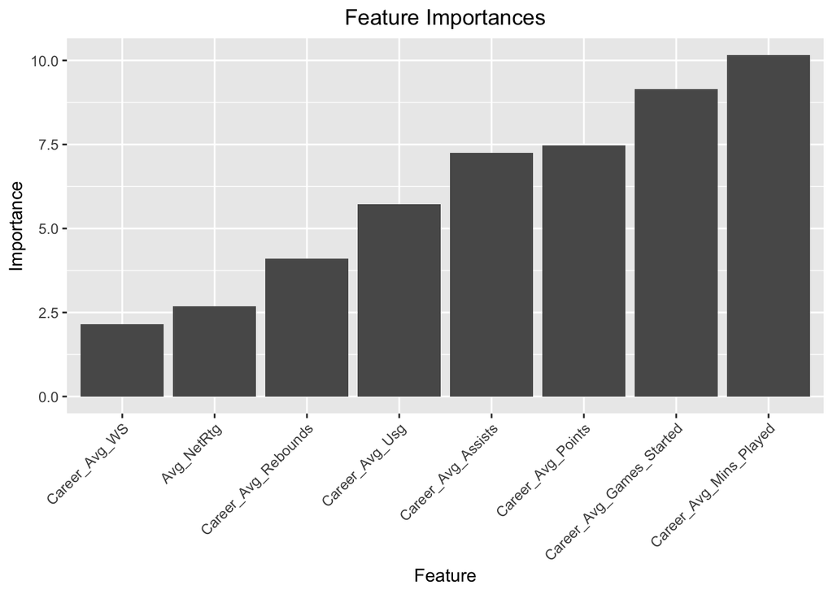

```r
library(ggplot2)
# Got feature importances from the Random Forest model
importances <- importance(model)

# Created a data frame for visualization
importance_df <- data.frame(Feature = rownames(importances), Importance = importances[, 1])

# Sorted the data frame by importance
importance_df <- importance_df %>% arrange(desc(Importance))

# Created a bar plot to visualize feature importances
ggplot(importance_df, aes(x = reorder(Feature, Importance), y = Importance)) +
  geom_bar(stat = "identity") +
  labs(title = "Feature Importances",
       x = "Feature",
       y = "Importance") +
   theme(axis.text.x = element_text(angle = 45, hjust = 1),
          plot.title = element_text(hjust = 0.5))
```

**Predictions for Shai Gilgeous-Alexander, Zion Williamson, James Wiseman, and Josh Giddey**

**Shai:** The model overall did Shai kinda dirty. Obviously his massive 2022 season wasn’t included so that plays a huge role. The model says he’ll end up a starter with also a high probability of ending up an all-star. I think if you include 2022, the model would say that he’ll end up an all-star but with a high probability of elite and if I were a betting man I’d say he’ll reach that Elite outcome when it’s all said and done.

**Zion:** The model was better to Zion. I think it gave pretty accurate results on him. The model says of all the outcomes, he’s most likely to become elite which I’d say is very accurate. When Zion is playing, Zion is dominant. I wish I could use injury and off court behavior data exactly for players like Zion because that would’ve definitely altered his career outcome predictions. I’d say he’ll become elite when it’s all said and done but all star is currently a much safer pick for him.

**Wiseman:** I’m from the Bay Area so I’ve watched Wiseman a lot. Looking past all the data, just my personal opinion, I don’t think he passes the eye test and tends to look out of place or uncomfortable a lot of the time when playing. Maybe that’s because he just didn’t fit Golden State but many fundamentals were just not there. And the data (kinda) backs me up. It says he’s most likely to be out of the league but he’s also pretty likely to be a starter. I think the starter outcome comes from how he had a decent ppg but generally I think starter is not looking too likely for him. I think out of the league may be a bit harsh as he still has some pretty impressive raw athleticism that teams could use but I’d definitely say he’ll end up with a roster outcome honestly. The 2023 season will be a big one for him to prove his worth and for the data/model to better understand his career outlook.

**Giddey:** I love Josh Giddey, both his play style and his personality from all the videos I see online. The model says he’ll be a starter. I think that’s pretty accurate. Maybe Giddey makes an all-star game once or twice but I generally think as long as he’s playing in this setup on the Thunder he’ll be a high impact starter who helps teams win games.

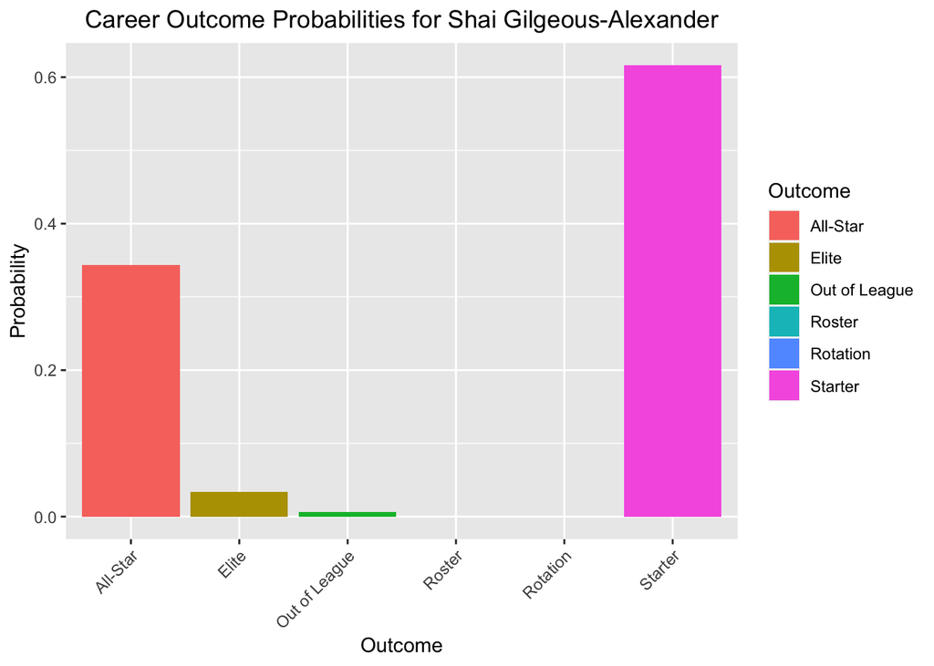

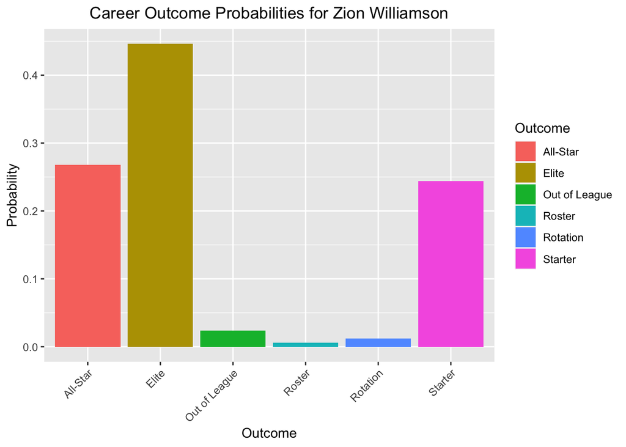

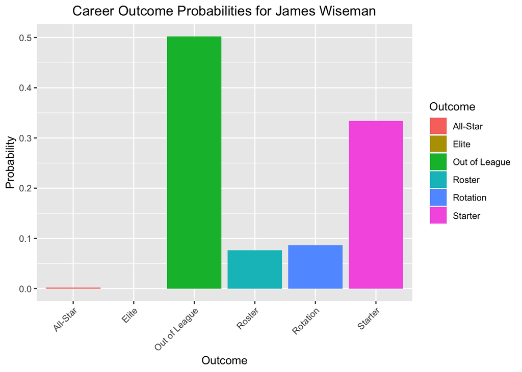

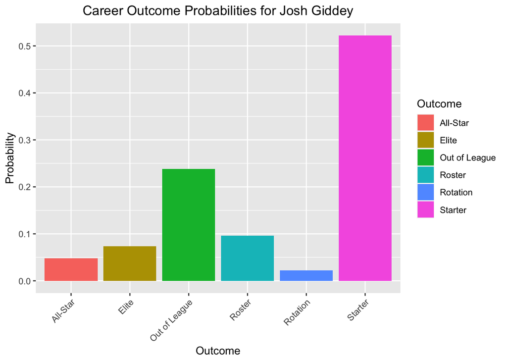

```r
library(ggplot2)

# Selected the players I wanted to visualize
selected_players <- predicted_testdata %>%
  filter(player %in% c("Shai Gilgeous-Alexander", "Zion Williamson", "James Wiseman", "Josh Giddey"))

# Reshaped the data for plotting
selected_players_long <- selected_players %>%
  pivot_longer(cols = c("Elite", "All-Star", "Starter", "Rotation", "Roster", "Out of League"),
               names_to = "Outcome", values_to = "Probability")

# Created a separate graph for each player
plots <- list()
for (player_name in unique(selected_players$player)) {
  player_data <- selected_players_long %>%
    filter(player == player_name)

  plot <- ggplot(player_data, aes(x = Outcome, y = Probability, fill = Outcome)) +
    geom_bar(stat = "identity") +
    labs(title = paste("Career Outcome Probabilities for", player_name),
         x = "Outcome",
         y = "Probability") +
    theme(axis.text.x = element_text(angle = 45, hjust = 1),
          plot.title = element_text(hjust = 0.5))

  plots[[player_name]] <- plot
}

# Displayed the plots
for (player_name in unique(selected_players$player)) {
  print(plots[[player_name]])
}
```

**HTML Table**: Career Outcome probability predictions for the players drafted in 2019-2021

```r
library(reactable)

# Filtered the dataframe to include only players drafted between 2019 and 2021
htmldata <- predicted_testdata %>%
  filter(draftyear >= 2019)

# Selected the columns I wanted to display to make it more readable
columns_to_display <- c("player", "All-Star", "Elite", "Out of League", "Roster", "Rotation", "Starter")

# Created a subset of the dataframe with the selected columns
htmldata_subset <- htmldata[columns_to_display]

# Created an HTML table from the filtered and selected dataframe
reactable(htmldata_subset)
```

| player | All-Star | Elite | Out of League | Roster | Rotation | Starter |
| --- | --- | --- | --- | --- | --- | --- |
| Charlie Brown | 0 | 0 | 0.838 | 0.152 | 0.01 | 0 |
| Cam Reddish | 0 | 0 | 0.43 | 0.078 | 0.076 | 0.416 |
| Bruno Fernando | 0 | 0 | 0.96 | 0.04 | 0 | 0 |
| De'Andre Hunter | 0 | 0.002 | 0.41 | 0.038 | 0.042 | 0.508 |
| Donta Hall | 0 | 0 | 0.552 | 0.318 | 0.122 | 0.008 |
| Nicolas Claxton | 0 | 0 | 0.388 | 0.084 | 0.432 | 0.096 |
| Grant Williams | 0 | 0 | 0.74 | 0.046 | 0.19 | 0.024 |
| Tremont Waters | 0 | 0 | 0.77 | 0.204 | 0.026 | 0 |
| Tacko Fall | 0 | 0 | 0.754 | 0.24 | 0.006 | 0 |
| Carsen Edwards | 0 | 0 | 0.928 | 0.07 | 0.002 | 0 |

[output cut: 197 more lines]

## Part 2 – Predicting Team Stats

In this section, I devised a simple way to predict team offensive rebound percent in the next game and then discussed ways to improve those predictions.

### Question 1

Using the 2022 team rebounding dataset, I predicted a team’s next game’s offensive rebounding percent to be their average offensive rebounding percent in all prior games. On a single game level, offensive rebounding percent is the number of offensive rebounds divided by their number offensive rebound “chances” (essentially the team’s missed shots). On a multi-game sample, it should be the total number of offensive rebounds divided by the total number of offensive rebound chances.

This being a OKC Thunder centric project, I decided on my specific question to focus on calculating what OKC’s predicted offensive rebound percent is for game 81 in the data.

```r
# Filtered data for OKC's games
okc_data <- rebounding_data %>%
  filter(team == "OKC" & game_number <= 80)

# Calculated total offensive rebounds and total offensive rebound chances for games 1-80
total_off_rebounds <- sum(okc_data$offensive_rebounds)
total_off_rebound_chances <- sum(okc_data$off_rebound_chances)

# Calculated average offensive rebound percentage for games 1-80
average_off_rebound_pct <- total_off_rebounds / total_off_rebound_chances

# Predicted OKC's offensive rebound percentage for game 81
predicted_off_rebound_pct <- average_off_rebound_pct

# Printed the predicted offensive rebound percentage
cat("Predicted Offensive Rebound Percentage for OKC in game 81:", predicted_off_rebound_pct, "\n")
```

```
## Predicted Offensive Rebound Percentage for OKC in game 81: 0.2886898
```

**ANSWER 1:**

28.9%

### Question 2

There are a few limitations to the method used above. For example, if a team has a great offensive rebounder who has played in most games this season but will be out due to an injury for the next game, we might reasonably predict a lower team offensive rebound percent for the next game.

Below I discuss how I would think about changing the original model to better account for missing players, if I were working for a basketball team.

**ANSWER 2:**

**Incorporate Player-Specific Offensive Rebounding Percentages:** Instead of relying solely on team-level offensive rebounding percentages, we could include the offensive rebounding percentages for each player on OKC. Luckily this would be quite easy to do as the player statistics dataset already includes individual offensive rebounding percentages per player. Now when key offensive rebounders, in OKC’s case players like Josh Giddey (guards who can rebound!) or Kenrich Williams are unavailable due to injury or other reasons, we can adjust the team’s predicted offensive rebounding rate based on the missing player’s average contribution.

### Question 3

Adding on to question 2, here are 1-3 other potential weaknesses of the simple average model I made in question 1 and how I would deal with each of them.

**ANSWER 3:**

**1.Varying Strength of Opponents**: The simple average model treats all games equally and calculates the average offensive rebounding rate regardless of the quality of the opposing teams. This is problematic as OKC will face strong defensive rebounding teams/players or even teams with specific strategies to limit offensive rebounds.

Solution: Incorporate opponent-specific factors into the model. Gather data on opponent defensive rebounding rates, team playing styles especially strategies that may limit offensive rebounds, and other relevant metrics. Adjust the team’s offensive rebounding prediction based on the strength of the opponent which will be based on these factors. For instance, if facing a team with a high defensive rebounding rate, predict a slightly lower offensive rebounding rate for the team.

**2.Home and Away Games**: I don’t think this factor is as important as it’s made out to be especially during the playoffs when game dynamics completely change and every step becomes much more thought-out/strategic and unpredictable. However, the model does not account for home-court advantage, which could very well impact offensive rebounding rates. Teams might perform differently in home vs. away games because of factors like crowd support and general familiarity with the court.

Solution: Include a home/away indicator in the model. Analyze historical data to determine whether offensive rebounding rates differ significantly between home and away games. Adjust the predicted offensive rebounding rate based on whether the game is played at home or away.

**3.Player Fatigue and Game Flow**: The model assumes a constant offensive rebounding rate across all games, disregarding player fatigue, injuries, and the impact of the team’s game sequence. Players might perform differently in back-to-back games or during busy stretches of the season.

Solution: This is difficult to solve due to it dealing with player health: physical, mental, and emotional. However, a solution could be to gather data on player rest days, injury history, and game density. Use this information to adjust the predicted offensive rebounding rate. For example, if the data confirms it, predict a slightly lower offensive rebounding rate for games following intense stretches (long road trips, 5 games in 7 days, long overtime games, etc.) or for players with a history of underperforming in certain game stretches or that are coming off of injuries.

However, instead of incorporating these changes into the existing model, we’d be better equipped using new technology that exists today and training a machine learning model such as a time series model with all these solutions incorporated within it.

# Conclusion

Overall, I’m thrilled with how this NBA data science project turned out, especially given the general nature of the datasets used. By leveraging player stats, awards, and team data from 2007-2021, I was able to explore intriguing questions and develop a model to predict career outcomes based on early performance. While not perfect, I believe the career predictor in particular showcases the power of data analysis to forecast future success.

My hope is that readers learned a thing or two from this passion project, because I certainly did! Not only did I strengthen my R programming and data science skills, I gained fresh basketball insights by taking an analytical approach. Though basic in nature, this first attempt only scratches the surface of possible basketball analysis.

Moving forward, I’m eager to refine my data science abilities and statistical knowledge and work on new projects as the field continues expanding. Sports like basketball offer great opportunities to practice collecting, cleaning, analyzing, and visualizing data but this work isn’t reserved to just sports which makes me extremely excited because the possibilities are truly endless! With this hands-on learning experience under my belt, I look forward to seeing where continued curiosity and growth in data science may lead!